# Data Exploratory Analysis

Simone Zanetti

19/6/2018

The following section provides an exploratory analysis of the data available for this project. At first, a generic analysis of the company will be performed to observe the situation and address eventual trends. After that, aggregate data will be created in order to obtain the dependent variable of interest which is the ratio between deliveries and number of worked hours. Each dependent variable is referred to a driver, that is the statistical unit of this analysis. In conclusion, an analysis of the relationship between the y - dependent variable - and each independent variable will be performed in order to analyse the situation.

The following codes need a series of packages to be installed in order to perform the analysis:

```r
library(tidyr)
library(dplyr)
library(chron)
library(ggmap)
```

```r
library(ggplot2)
library(ggplot2)
library(ggthemes)
load("Data_exploratory.RData")
```

# GENERICAL TREND OF THE COMPANY

## DAYS OF THE MONTH

The data frame and the plot obtained by the codes below can be summarised as following:

```
##  driver_code         day_deliv         tot_deliveries
##  Length:1882        Length:1882        Min.   :  1.00
##  Class :character   Class :character   1st Qu.: 72.00
##  Mode  :character   Mode  :character   Median : 82.00
##                                        Mean   : 78.05
##                                        3rd Qu.: 90.00
##                                        Max.   :143.00
```

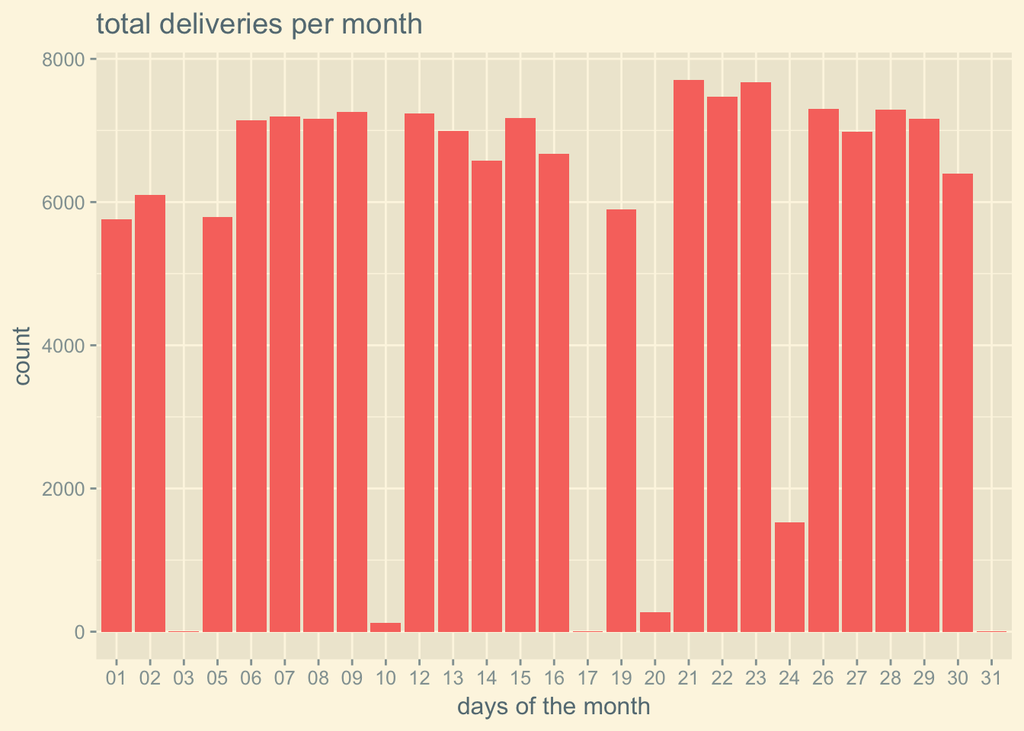

```r
stronger_day <- deliveries_day_driver %>% group_by(day_deliv) %>% summarise(tot_deliveries = sum(tot_deliveries))
stronger_day <- stronger_day %>% arrange(desc(tot_deliveries))

head(stronger_day)
```

```
## # A tibble: 6 x 2
##   day_deliv tot_deliveries
##   <chr>              <dbl>
## 1 21                 7704.
## 2 23                 7676.
## 3 22                 7469.
## 4 26                 7303.
## 5 28                 7292.
## 6 09                 7258.
```

```r
tail(stronger_day)
```

```
## # A tibble: 6 x 2
##   day_deliv tot_deliveries
##   <chr>              <dbl>
## 1 24                 1529.
## 2 20                  277.
## 3 10                  118.
## 4 17                    9.
## 5 31                    3.
## 6 03                    2.
```

```r
summary(stronger_day)
```

```
##   day_deliv         tot_deliveries
##  Length:27          Min.   :   2
##  Class :character   1st Qu.:5776
##  Mode  :character   Median :6984
##                     Mean   :5441
##                     3rd Qu.:7216
##                     Max.   :7704
```

The chart shows the 21, 23 and 22 to be the days with more deliveries and this is apparently coherent with the fact that the 20 March a strike paralized the normal activity of the company. The Mean of deliveries per day is 5441 with a Median of 6984 suggesting a distribution skewed to the left.

## ANALYSIS OF WEEKDAYS

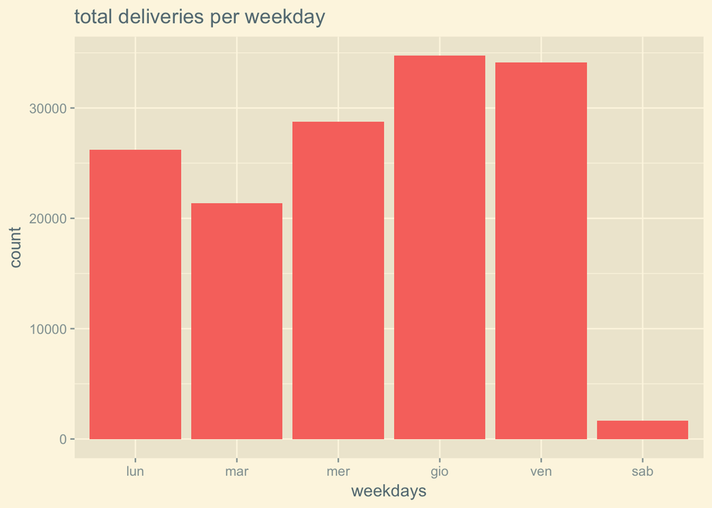

```r
data_exploratory$weekday_deliv <- factor(x = data_exploratory$weekday_deliv, levels = c("lun","mar","mer","gio","ven","sab"))


stronger_weekday_driver <- data_exploratory %>% group_by(driver_code,weekday_deliv) %>% summarise(tot_delivery = sum(delivery))

stronger_weekday <- data_exploratory %>% group_by(weekday_deliv) %>% summarise(tot_delivery = sum(delivery))


weekday_plot <- ggplot(data = data_exploratory, aes(x = weekday_deliv, fill = "indianred2")) +
  theme_solarized_2()+ labs(title = "total deliveries per weekday", x = "weekdays") + guides(fill = FALSE)
weekday_plot + geom_bar()
```

As aforementioned described, these data can be misleading due to the reasons previously described. To overcome this, two possibilites:

### 1) Use the Mean

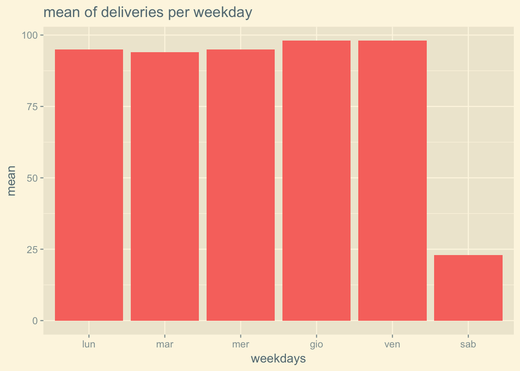

```r
weekday_mean <- stronger_weekday_driver %>% group_by(weekday_deliv) %>% summarise(mean = mean(n()))


weekday_mean_plot <- ggplot(data = weekday_mean, aes(x = weekday_deliv, y = mean, fill = "indianred2")) +
  theme_solarized_2()
weekday_mean_plot + geom_col()+ labs(title = "mean of deliveries per weekday", x = "weekdays") + guides(fill = FALSE)
```

### 2) WORK WITH COMPLETE WEEKS ONLY

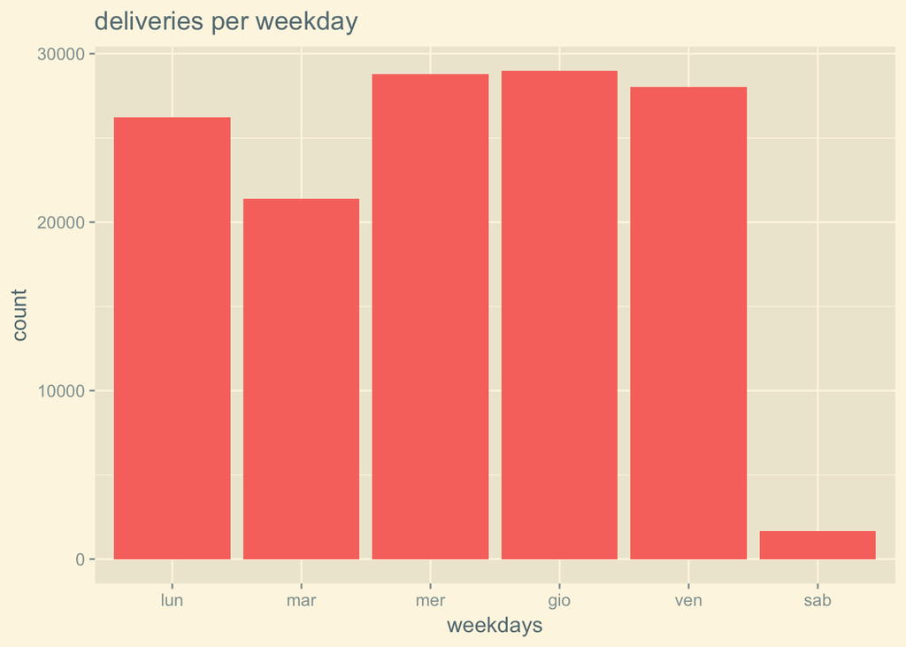

```r
data_strongerweekdays <- data_exploratory %>% filter(data_exploratory$day_deliv != "01",
                                                     data_exploratory$day_deliv != "02",
                                                     data_exploratory$day_deliv != "03")


weekday2_plot <- ggplot(data = data_strongerweekdays, aes(x = weekday_deliv, fill = "indianred2")) +
  theme_solarized_2()
weekday2_plot + geom_bar()+ labs(title = "deliveries per weekday", x = "weekdays") + guides(fill = FALSE)
```

The following codes aimed to deepen the analysis to observe if weekdays can be significantly influenced by other variables such as the driver, the day of delivery and the range of hour.

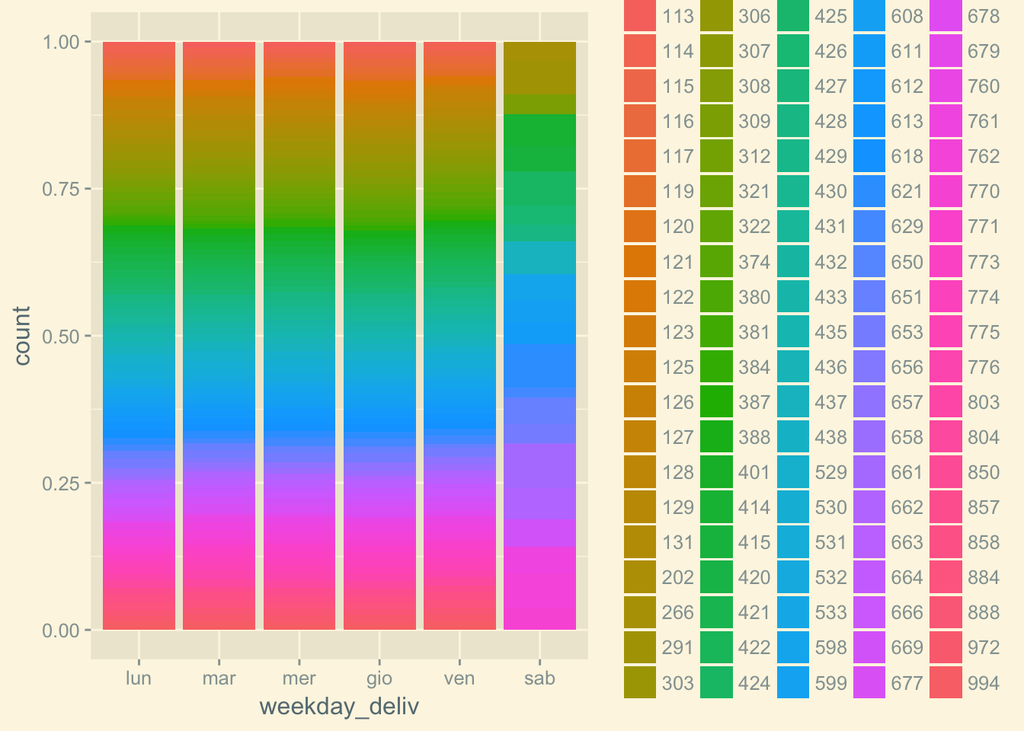

```r
weekday2_plot + aes(fill = driver_code) + geom_bar(position = "fill")
```

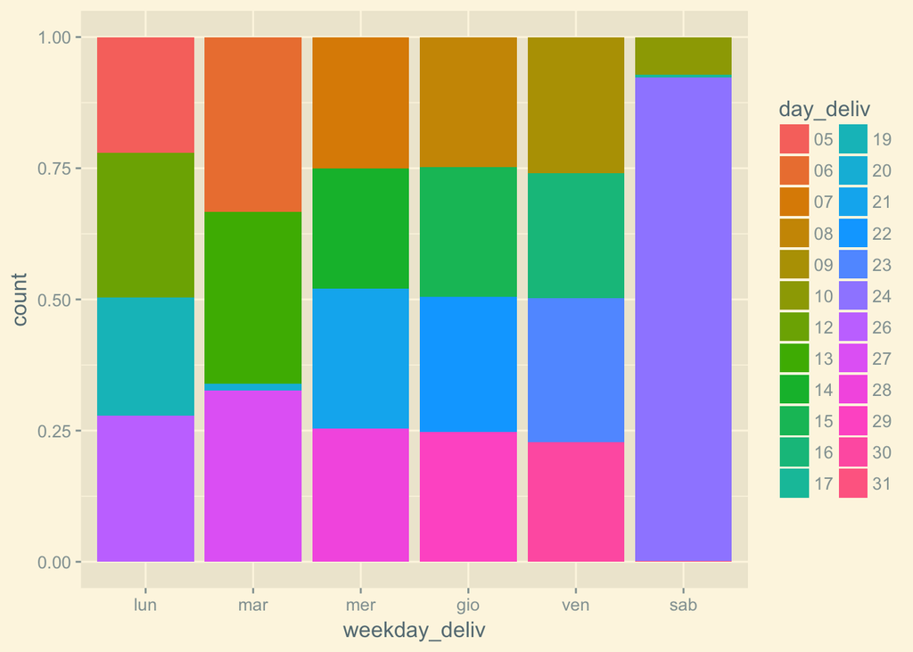

```r
weekday2_plot + aes(fill = day_deliv) + geom_bar(position = "fill")
```

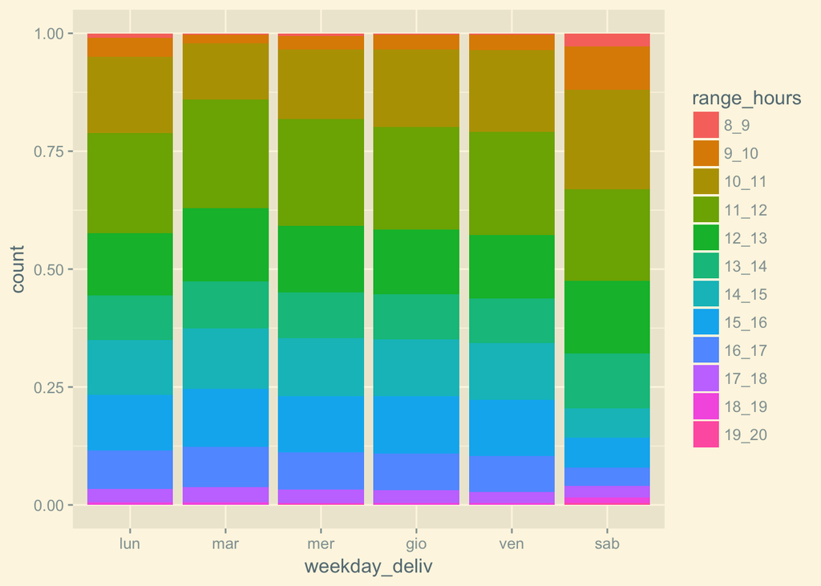

```r
weekday2_plot + aes(fill = range_hours) + geom_bar(position = "fill")
```

## ANALYSIS OF THE TIME OF DELIVERY

### Creating of Range Hours from the variable pickedup_time

```r
data_exploratory = data_exploratory %>% mutate(range_hours = sub(pattern = "^08.*", replacement = "8_9",x = pickup_time),
                                               range_hours = sub(pattern = "^09.*", replacement = "9_10",x = range_hours),
                                               range_hours = sub(pattern = "^10.*", replacement = "10_11",x = range_hours),
                                               range_hours = sub(pattern = "^11.*", replacement = "11_12",x = range_hours),
                                               range_hours = sub(pattern = "^12.*", replacement = "12_13",x = range_hours),
                                               range_hours = sub(pattern = "^13.*", replacement = "13_14",x = range_hours),
                                               range_hours = sub(pattern = "^14.*", replacement = "14_15",x = range_hours),
                                               range_hours = sub(pattern = "^15.*", replacement = "15_16",x = range_hours),
                                               range_hours = sub(pattern = "^16.*", replacement = "16_17",x = range_hours),
                                               range_hours = sub(pattern = "^17.*", replacement = "17_18",x = range_hours),
                                               range_hours = sub(pattern = "^18.*", replacement = "18_19",x = range_hours),
                                               range_hours = sub(pattern = "^19.*", replacement = "19_20",x = range_hours),
                                               range_hours = sub(pattern = "^20.*", replacement = "20_21",x = range_hours))





unique(data_exploratory$range_hours)
```

```
##  [1] "15_16" "16_17" "11_12" "14_15" "13_14" "12_13" "17_18" "10_11"
##  [9] "9_10"  "18_19" "8_9"   "19_20"
```

```r
data_exploratory = data_exploratory %>% filter(range_hours != "20_21" & range_hours != "06:51:00")

data_exploratory$range_hours <- factor(x = data_exploratory$range_hours, levels = c("8_9","9_10","10_11","11_12","12_13","13_14","14_15","15_16","16_17","17_18","18_19", "19_20"))
```

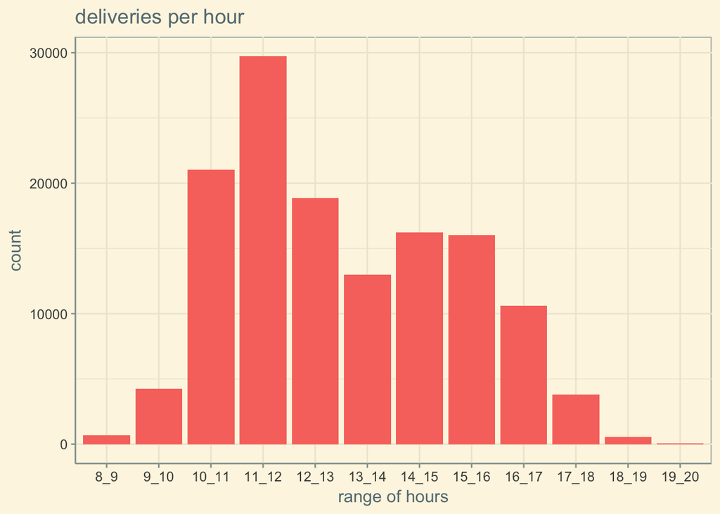

```r
stronger_hour <- data_exploratory %>% group_by(driver_code,range_hours) %>% summarise(tot_deliveries = sum(delivery))

data_strongerhours <- data_exploratory %>% filter(data_exploratory$day_deliv != "01",
                                                  data_exploratory$day_deliv != "02",
                                                  data_exploratory$day_deliv != "20")


strongerhour_plot <- ggplot(data = data_strongerhours, aes(x = range_hours, fill= "indianared2")) + theme_solarized()+
  labs(title = "deliveries per hour", x = "range of hours")

strongerhour_plot + geom_bar() +  guides(fill = FALSE)
```

The plot shows a peak of deliveries on the range between 11 am and 12 pm. After that range, the curve regularly decreases until the end of the day with the exepction of the range between 13 and 14, where the number of deliveries decreases before to increase again on the following range. From this point of view, the morning between 10 and 13 the majority of the deliveres are done.

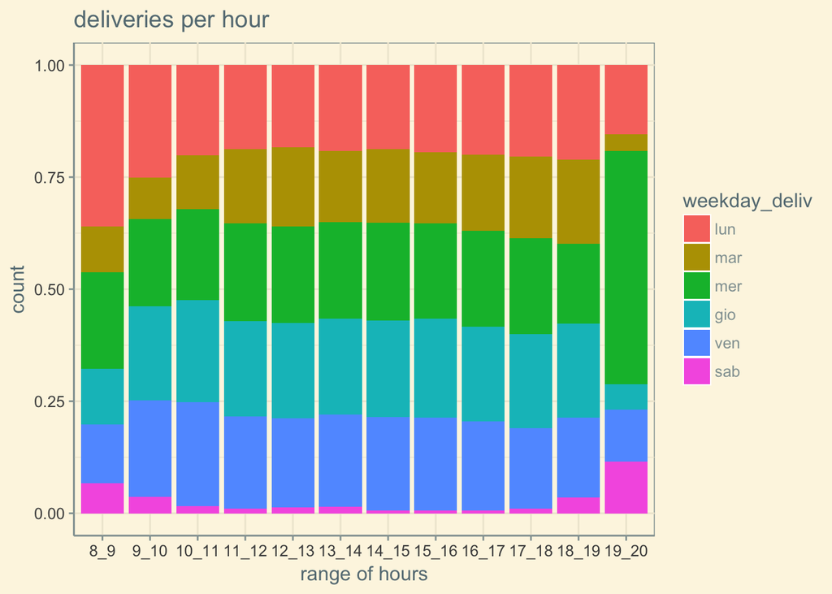

```r
strongerhour_plot + aes(fill = weekday_deliv) + geom_bar(position = "fill")
```

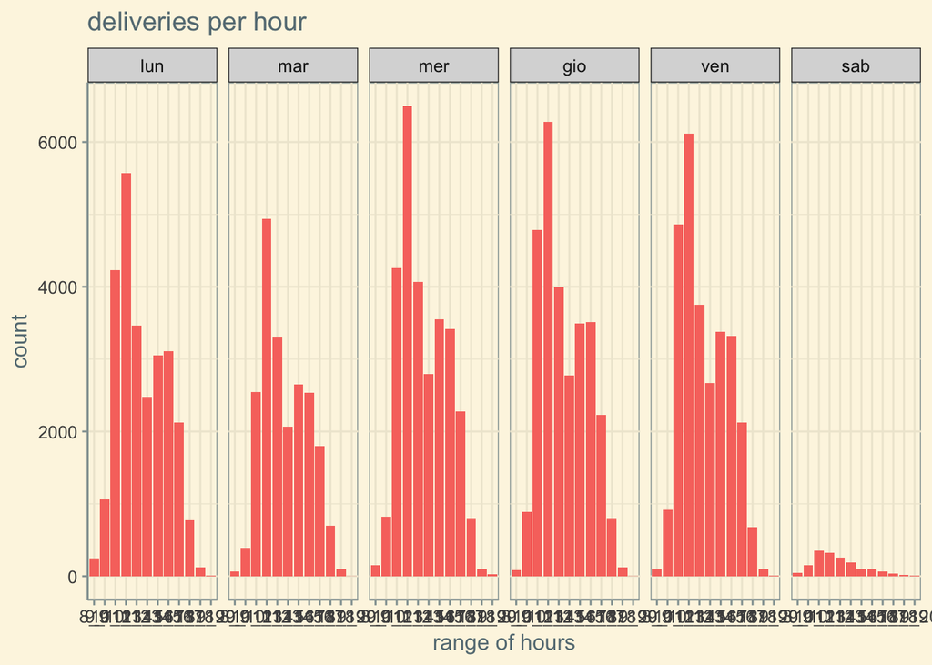

```r
strongerhour_plot + geom_bar() + facet_grid(.~data_strongerhours$weekday_deliv)+  guides(fill = FALSE)
```

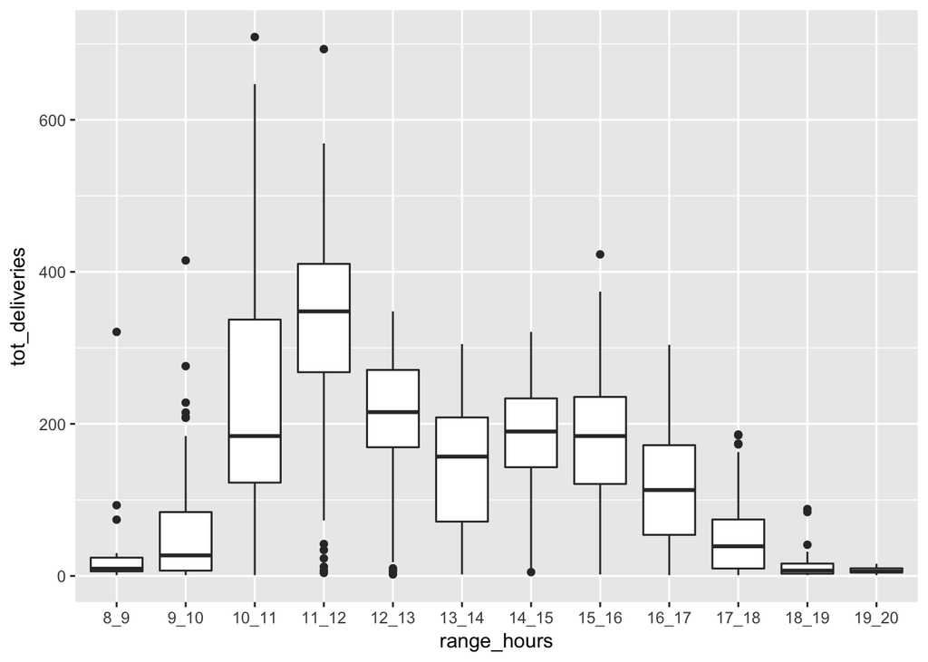

```r
ggplot(data = stronger_hour, aes(x = range_hours, y = tot_deliveries))+ geom_boxplot()
```